# Evaluating Kinder Readiness using MCLASS and TXKEA

### Purpose

1) A SQL query you have written to aggregate and extract necessary data from the database,

2) A data cleaning/analysis script,

3) A brief narrative which describes key findings with data visualizations

## SQL Query

WITH test_data AS (

SELECT student_id,

district_id,

composite_level,

assessment_edition,

CASE WHEN

composite_level IN

('Well Below Benchmark',

'Below Benchmark') THEN 0

ELSE 1 END

AS passed,

'MCLASS' AS test_taken

FROM MCLASS

WHERE assessment_edition = 'DIB%'

UNION ALL

SELECT student_id,

district_id,

language,

lit_screening_benchmark,

CASE WHEN

lit_screening_benchmark IN

('Montior',

'Support') THEN 0

ELSE 1 END

AS passed,

'TXKEA' AS test_taken

FROM TXKEA

WHERE language = 'English'

)

SELECT test_data.student_id,

test_data.district_id,

test_data.test_taken,

test_data.passed,

DEMO.ethnicity,

DEMO.eco,

DEMO.spec_ed,

DEMO.el

FROM test_data

LEFT JOIN DEMO

ON

test_data.student_id = DEMO.student_id ;

## Data Cleaning and Prep

### Import the Libraries and Load the dataset

```python
# import libraries for data manipulation
import numpy as np
import pandas as pd

# import libraries for data visualization
import matplotlib.pyplot as plt
import seaborn as sns
```

```python
df = pd.read_csv('test_data.csv')
```

```
C:\Users\Cristi Mar\anaconda3\lib\site-packages\IPython\core\interactiveshell.py:3444: DtypeWarning: Columns (0) have mixed types.Specify dtype option on import or set low_memory=False.
  exec(code_obj, self.user_global_ns, self.user_ns)
```

```python
df.head() #view the first few rows
```

|  | student_id | district_id | test_taken | passed | ethnicity | eco | sped | el |
| --- | --- | --- | --- | --- | --- | --- | --- | --- |
| 0 | 885938600 | 53405.0 | TXKEA | 1 | White | YES | NO | NO |
| 1 | 871944576 | 798403.0 | TXKEA | 1 | Black or African American | YES | NO | NO |
| 2 | 818725252 | 53405.0 | TXKEA | 1 | White | NO | NO | NO |
| 3 | 702015143 | 800409.0 | TXKEA | 1 | White | YES | YES | NO |
| 4 | 717968813 | 48403.0 | TXKEA | 1 | Two or more races | YES | NO | NO |

### Evaluate data for errors and cleaning

```python
df.info() # Check the datatypes of columns
```

```
<class 'pandas.core.frame.DataFrame'>
RangeIndex: 150712 entries, 0 to 150711
Data columns (total 8 columns):
 #   Column       Non-Null Count   Dtype
---  ------       --------------   -----
 0   student_id   150712 non-null  object
 1   district_id  145415 non-null  float64
 2   test_taken   150712 non-null  object
 3   passed       150712 non-null  int64
 4   ethnicity    150712 non-null  object
 5   eco          150712 non-null  object
 6   sped         150712 non-null  object
 7   el           150712 non-null  object
dtypes: float64(1), int64(1), object(6)
memory usage: 9.2+ MB
```

```python
df.isnull().sum() #Checking to find null values
```

```
student_id        0
district_id    5297
test_taken        0
passed            0
ethnicity         0
eco               0
sped              0
el                0
dtype: int64
```

```python
df.describe(include='all').T #Look at the columns for possible outliers
```

|  | count | unique | top | freq | mean | std | min | 25% | 50% | 75% | max |
| --- | --- | --- | --- | --- | --- | --- | --- | --- | --- | --- | --- |
| student_id | 150712.0 | 150025.0 | 5315199254.0 | 4.0 | NaN | NaN | NaN | NaN | NaN | NaN | NaN |
| district_id | 145415.0 | NaN | NaN | NaN | 516617.655696 | 367590.16558 | 1403.0 | 74408.0 | 772409.0 | 808489.0 | 899408.0 |
| test_taken | 150712 | 2 | TXKEA | 94563 | NaN | NaN | NaN | NaN | NaN | NaN | NaN |
| passed | 150712.0 | NaN | NaN | NaN | 0.665149 | 0.47194 | 0.0 | 0.0 | 1.0 | 1.0 | 1.0 |
| ethnicity | 150712 | 7 | Hispanic/Latino | 69047 | NaN | NaN | NaN | NaN | NaN | NaN | NaN |
| eco | 150712 | 2 | YES | 89425 | NaN | NaN | NaN | NaN | NaN | NaN | NaN |
| sped | 150712 | 2 | NO | 139409 | NaN | NaN | NaN | NaN | NaN | NaN | NaN |
| el | 150712 | 2 | NO | 131058 | NaN | NaN | NaN | NaN | NaN | NaN | NaN |

```python
df['district_id'] = df['district_id'].astype(object)
```

```python
df.describe(include='all').T #Recheck values after recasting 'district_id' as object
```

|  | count | unique | top | freq | mean | std | min | 25% | 50% | 75% | max |
| --- | --- | --- | --- | --- | --- | --- | --- | --- | --- | --- | --- |
| student_id | 150712.0 | 150025.0 | 5315199254.0 | 4.0 | NaN | NaN | NaN | NaN | NaN | NaN | NaN |
| district_id | 145415.0 | 735.0 | 801102.0 | 5832.0 | NaN | NaN | NaN | NaN | NaN | NaN | NaN |
| test_taken | 150712 | 2 | TXKEA | 94563 | NaN | NaN | NaN | NaN | NaN | NaN | NaN |
| passed | 150712.0 | NaN | NaN | NaN | 0.665149 | 0.47194 | 0.0 | 0.0 | 1.0 | 1.0 | 1.0 |
| ethnicity | 150712 | 7 | Hispanic/Latino | 69047 | NaN | NaN | NaN | NaN | NaN | NaN | NaN |
| eco | 150712 | 2 | YES | 89425 | NaN | NaN | NaN | NaN | NaN | NaN | NaN |
| sped | 150712 | 2 | NO | 139409 | NaN | NaN | NaN | NaN | NaN | NaN | NaN |
| el | 150712 | 2 | NO | 131058 | NaN | NaN | NaN | NaN | NaN | NaN | NaN |

## Analysis and Visualizations

### Univariate Analysis

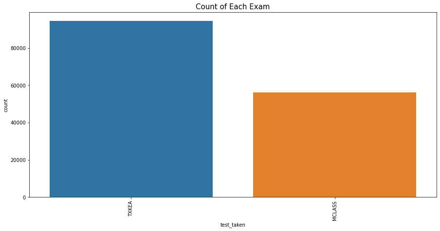

```python
plt.figure(figsize = (15, 7))
a=sns.countplot(data=df, x = 'test_taken')
plt.xticks(rotation=90)
a.set_title("Count of Each Exam", fontsize=15)
plt.show()
```

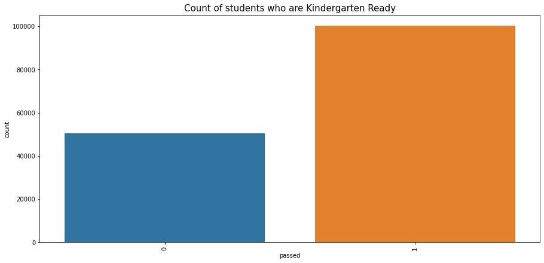

```python
plt.figure(figsize = (15, 7))
b=sns.countplot(data=df, x = 'passed')
plt.xticks(rotation=90)
b.set_title("Count of students who are Kindergarten Ready", fontsize=15)
plt.show()
```

#### About a 1/3 of the PreK students didn't meet kindergarten readiness.

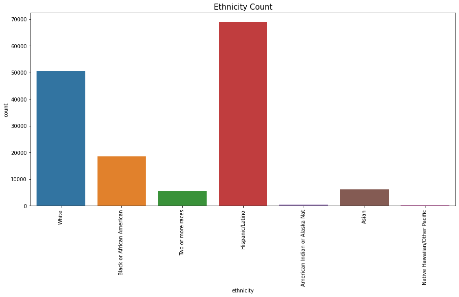

```python
plt.figure(figsize = (15, 7))
c=sns.countplot(data=df, x = 'ethnicity')
plt.xticks(rotation=90)
c.set_title("Ethnicity Count", fontsize=15)
plt.show()
```

#### We see that Hispanic is the predominant ethnicity.

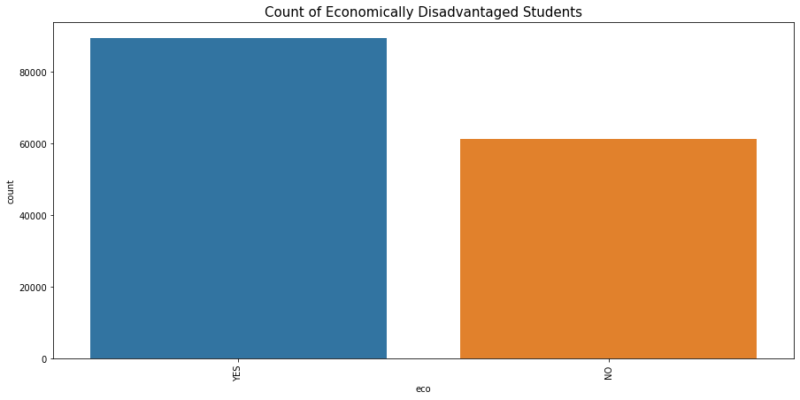

```python
plt.figure(figsize = (15, 7))
d=sns.countplot(data=df, x = 'eco')
plt.xticks(rotation=90)
d.set_title("Count of Economically Disadvantaged Students", fontsize=15)
plt.show()
```

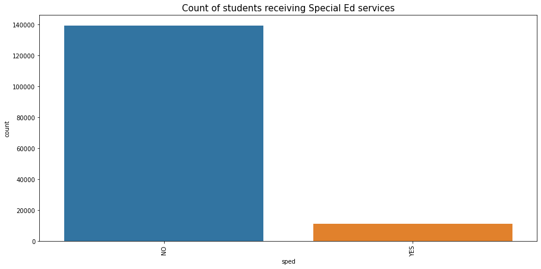

```python
plt.figure(figsize = (15, 7))
e=sns.countplot(data=df, x = 'sped')
plt.xticks(rotation=90)
e.set_title("Count of students receiving Special Ed services", fontsize=15)
plt.show()
```

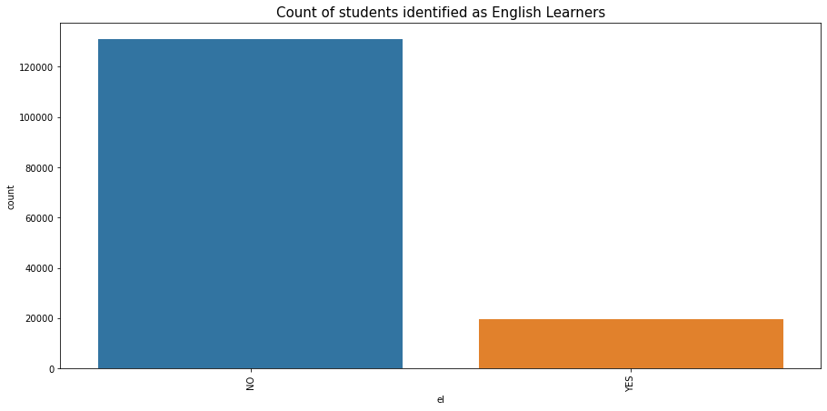

```python
plt.figure(figsize = (15, 7))
f=sns.countplot(data=df, x = 'el')
plt.xticks(rotation=90)
f.set_title("Count of students identified as English Learners", fontsize=15)
plt.show()
```

#### We see about 13% of the students are ELs who took the exam in English.

### Multivariate Analysis

```python
df_pass_eco=df.groupby(['eco', 'passed'])['student_id'].count().sort_values(ascending = False).reset_index()
## creates a df where students are aggregated by '1' Kinder Ready and '0' Not Ready
df_pass_eco
```

|  | eco | passed | student_id |
| --- | --- | --- | --- |
| 0 | YES | 1 | 52871 |
| 1 | NO | 1 | 47375 |
| 2 | YES | 0 | 36554 |
| 3 | NO | 0 | 13912 |

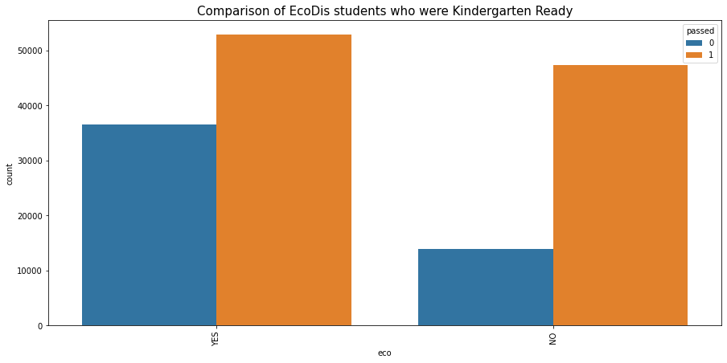

```python
plt.figure(figsize = (15, 7))
g=sns.countplot(data=df, x = 'eco', hue='passed')
plt.xticks(rotation=90)
g.set_title("Comparison of EcoDis students who were Kindergarten Ready", fontsize=15)
plt.show()
```

#### We can see that if a student is Economically Disadvantaged then you were much more likely to not be Kindergarten ready. Nearly 41% of EcoDis students were not ready as compared to 23% of students who were not EcoDis

```python
df_pass_eth=df.groupby(['ethnicity', 'passed'])['student_id'].count().reset_index()
## creates a df where students are aggregated by '1' Kinder Ready and '0' Not Ready
df_pass_eth
```

|  | ethnicity | passed | student_id |
| --- | --- | --- | --- |
| 0 | American Indian or Alaska Nat | 0 | 159 |
| 1 | American Indian or Alaska Nat | 1 | 274 |
| 2 | Asian | 0 | 844 |
| 3 | Asian | 1 | 5340 |
| 4 | Black or African American | 0 | 5364 |
| 5 | Black or African American | 1 | 13231 |
| 6 | Hispanic/Latino | 0 | 29108 |
| 7 | Hispanic/Latino | 1 | 39939 |
| 8 | Native Hawaiian/Other Pacific | 0 | 120 |
| 9 | Native Hawaiian/Other Pacific | 1 | 126 |
| 10 | Two or more races | 0 | 1387 |
| 11 | Two or more races | 1 | 4214 |
| 12 | White | 0 | 13484 |
| 13 | White | 1 | 37122 |

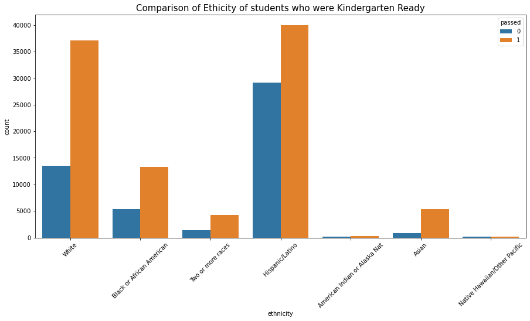

```python
plt.figure(figsize = (15, 7))
h=sns.countplot(data=df, x = 'ethnicity', hue='passed')
plt.xticks(rotation=45)
h.set_title("Comparison of Ethicity of students who were Kindergarten Ready", fontsize=15)
plt.show()
```

#### Native Hawaiian, Hispanic and Native Americans had the highest percentage of students not ready for Kinder.

```python
df_pass_sped=df.groupby(['sped', 'passed'])['student_id'].count().reset_index()
## creates a df where students are aggregated by '1' Kinder Ready and '0' Not Ready
df_pass_sped
```

|  | sped | passed | student_id |
| --- | --- | --- | --- |
| 0 | NO | 0 | 45511 |
| 1 | NO | 1 | 93898 |
| 2 | YES | 0 | 4955 |
| 3 | YES | 1 | 6348 |

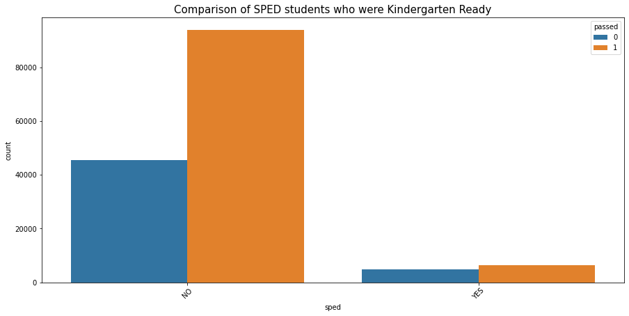

```python
plt.figure(figsize = (15, 7))
i=sns.countplot(data=df, x = 'sped', hue='passed')
plt.xticks(rotation=45)
i.set_title("Comparison of SPED students who were Kindergarten Ready", fontsize=15)
plt.show()
```

#### Students who needed SPED services were at 44% rate of not ready for Kinder as compared to the 33% who did not receive services.

```python
df_pass_el=df.groupby(['el', 'passed'])['student_id'].count().reset_index()
## creates a df where students are aggregated by '1' Kinder Ready and '0' Not Ready
df_pass_el
```

|  | el | passed | student_id |
| --- | --- | --- | --- |
| 0 | NO | 0 | 40577 |
| 1 | NO | 1 | 90481 |
| 2 | YES | 0 | 9889 |
| 3 | YES | 1 | 9765 |

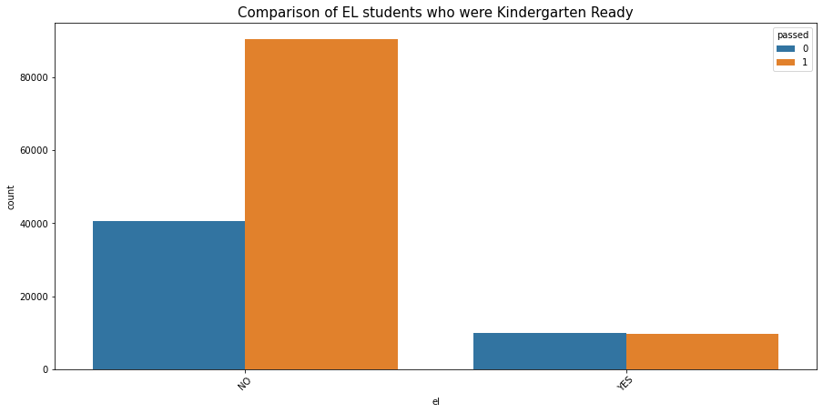

```python
plt.figure(figsize = (15, 7))
j=sns.countplot(data=df, x = 'el', hue='passed')
plt.xticks(rotation=45)
j.set_title("Comparison of EL students who were Kindergarten Ready", fontsize=15)
plt.show()
```

#### 1 in 2 EL students were not Kinder ready as compared to 31% of non EL students.

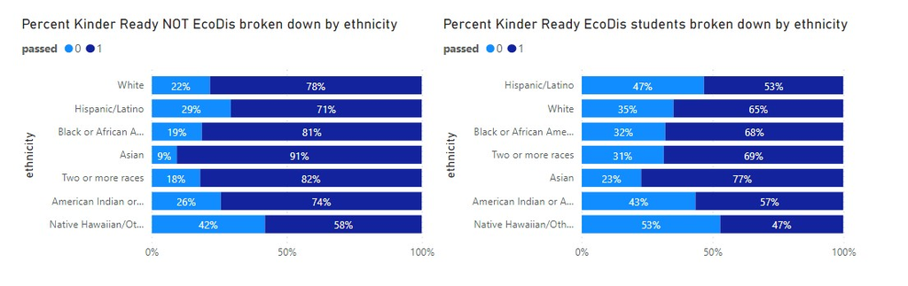

#### We can breakdown the information further and see how being Economically disadvantaged had a detrimental effect to Kinder Readiness across all ethnicities.

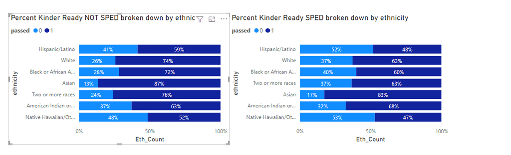

#### Again if you were offered SPED services you were more likely to not be ready for kinder for almost every race.

## Overall Findings and Next Steps

- Economically Disadvantaged students were less likely to be Kinder ready as were SPED and EL students.
- We know that Hispanics make up the largest ethnictiy and have the highest counts of EcoDis, SPED and EL.
- I would like to create a map of districts with their corresponding counts for Kinder readiness broken down for a demographic groups. This can be used fund intervention for districts that have more students labeled as EcoDis, SPED, and EL.